# ESM 244 Assignment 3

Alyssa Winchell

March 3, 2019

## Part 1: Open Science Perspectives

Open science aims to increase reproducibility of a study and facilitate accessibility to its data, methods, and software. The McKiernan et al paper (2016) also cites many studies that suggest open science practices result in more citations and media coverage than traditional methods. Open source publications also allow more freedom in author rights and control of reuse, which in addition to several other benefits, require attribution to the author, securing more citations and properly allocating credit. Additionally, because many prestigious organizations have taken several steps that encourage open science practices, participating in open science is becoming easier to fund.

Open science, however, is limited by the biases of the system that built it. While transparent peer review processes can increase the quality of their criticism and the rigorousness of their claims, it can also open up reviewers to backlash and responses based in unconscious biases based on their identities. Many of its other limitations come from its perception as less rigorous and prestigious, dissuading some scientists from participating out of fear for advancing their careers in a competitive environment. This can also be a limitation if a developing scientist interested in open science is working under a more experienced scientist that is not interested in that route due to concerns of prestige and thoroughness.

For example, the Oakology research group has documented all metadata in detail in one document. This metadata will ultimately be available on a published Shiny app which also displays the project’s inputs and outputs. Excluding data with sharing restrictions, all of the data files that we have created will be made publicly available and any data we have collected will be redistributed. Uploading code to GitHub, automating as much of our methods as possible through shareable code, and clearly documenting all research steps will increase the openness of our project and allow for reproducibility by our clients. Working on documents on Box and Google Docs also allows for openness with team members. Additionally, over the summer, my internship project with Eli Lilly only used open source data as inputs into its model so that proprietary data issues will not limit the applications of the research, although the model itself is proprietary. This project also required me to submit several Freedom of Information Act Requests (FOIAs) and public information requests, a useful skill for acquiring publicly available data that can be harder to actually access.

My Eli Lilly project could be more open by allowing their model to be open source. Currently, even users who have been allowed access to it are not allowed to use any code to interact with the program. This means that although creating the output for the 88 different scenarios required was very repetitive with a large room for error in setting up the program each time, scripts could not be made to automate the process. Allowing scripts would make accountability and troubleshooting much easier and would allow for those viewing the code to potentially catch typos or incorrect inputs. Research on pharmaceauticals in the United States is also very limited by governmental protections of company sales data. Because this data cannot be released without the permission of the company, researchers must either find other metrics for the amount of a given drug prescribed in the US or pay thousands of dollars for the required data. This means that researchers with no ties to the pharmaceutical companies will not have the means to accurately acquire the data, while company researchers that either have enough money or are given access to the data have conflicting interests.

## Part 2: Truckee River Flow (200 - 2016)

Attach Packages:

```r
suppressPackageStartupMessages(library(tidyverse))
suppressPackageStartupMessages(library(tseries))
suppressPackageStartupMessages(library(forecast))
suppressPackageStartupMessages(library(sf))
suppressPackageStartupMessages(library(tmap))
suppressPackageStartupMessages(library(leaflet))
suppressPackageStartupMessages(library(ggrepel))
suppressPackageStartupMessages(library(ggspatial))
suppressPackageStartupMessages(library(RColorBrewer))
suppressPackageStartupMessages(library(raster))
```

Load Data and Convert to Time Series Data:

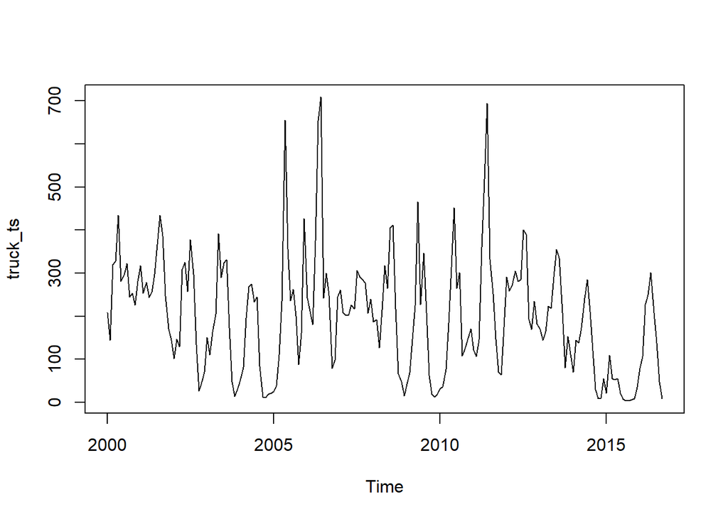

```r
truckee_flow <- read_csv("truckee_flow.csv")
truckee <- as.numeric(truckee_flow$mean_va) %>%
  na.omit()

truck_ts <- ts(truckee, frequency = 12, start = c(2000,1))

plot(truck_ts)
```

Decomposed Time Series Graph:

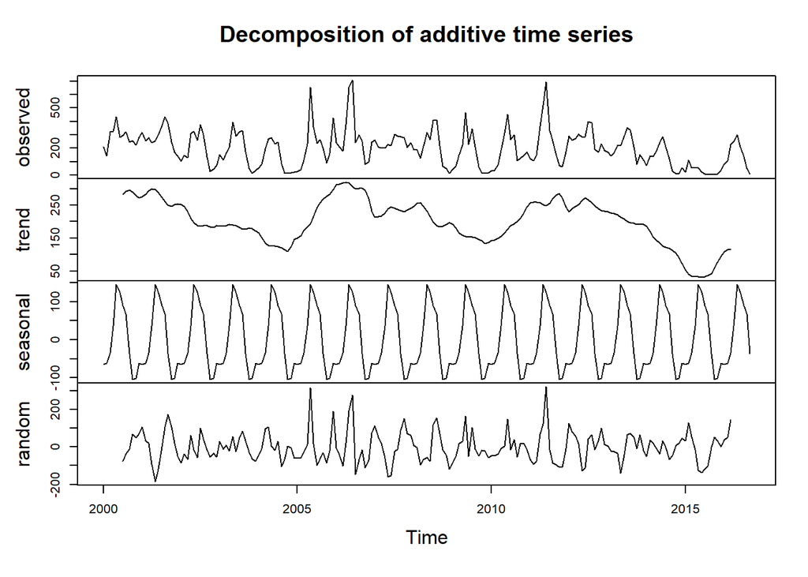

```r
truck_dec <- decompose(truck_ts)
plot(truck_dec)
```

Test if Stationary:

```r
adf_truck <- adf.test(truck_ts)
adf_truck
```

```
##
##  Augmented Dickey-Fuller Test
##
## data:  truck_ts
## Dickey-Fuller = -5.5387, Lag order = 5, p-value = 0.01
## alternative hypothesis: stationary
```

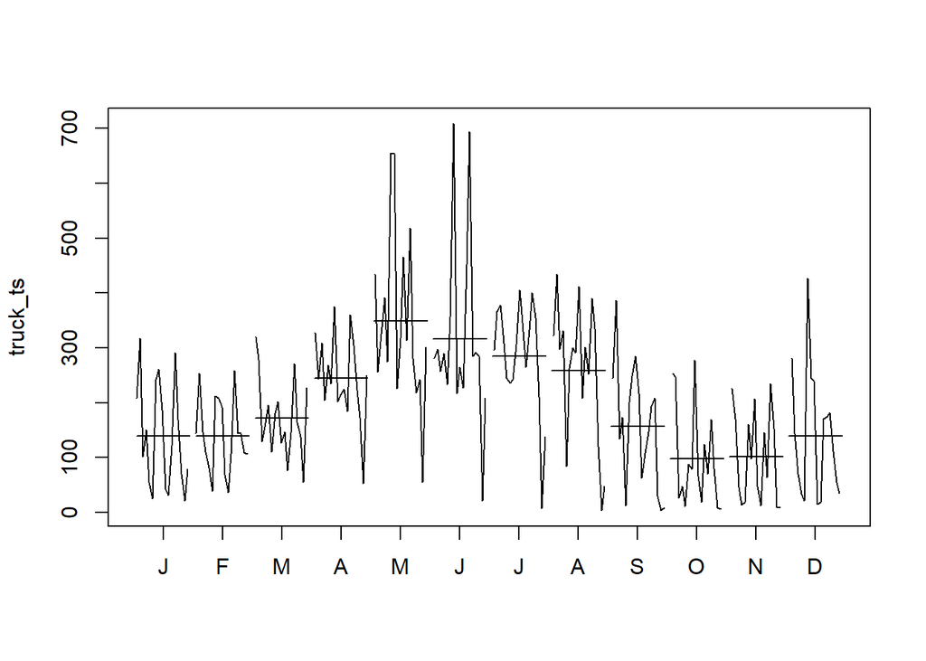

```r
#another plot
monthplot(truck_ts)
```

Forcasting Truckee River Flow: Holt Winters

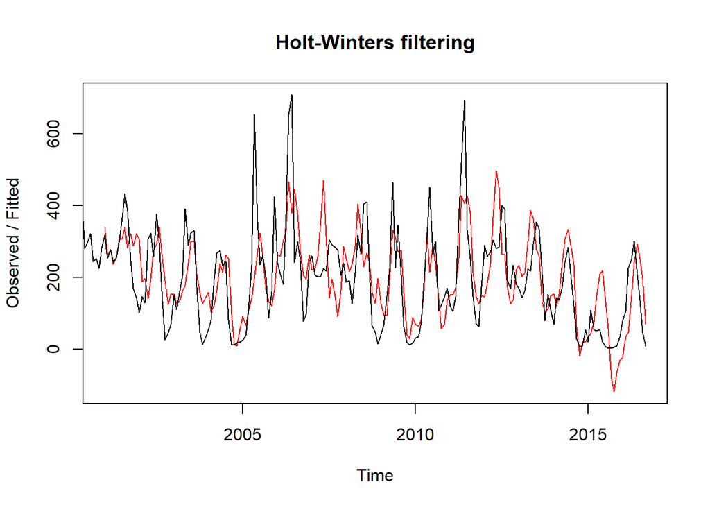

```r
truck_hw <- HoltWinters(truck_ts) #performs the Holt Winters
plot(truck_hw)
```

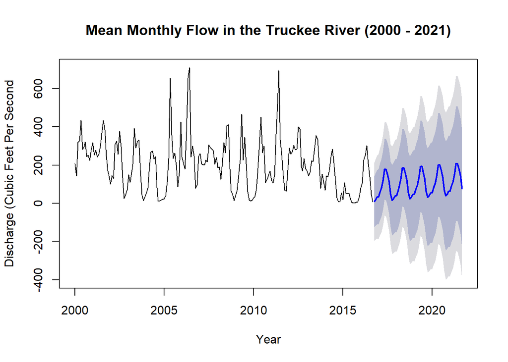

```r
truck_forecast <- forecast(truck_hw, h = 60) #forecast from HW
plot(truck_forecast, xlab = 'Year', ylab = 'Discharge (Cubic Feet Per Second', main = 'Mean Monthly Flow in the Truckee River (2000 - 2021)')
```

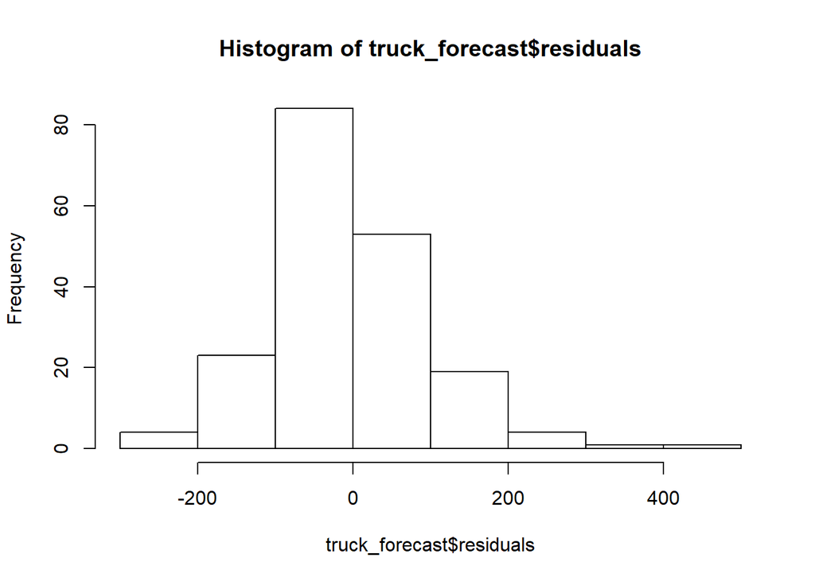

```r
hist(truck_forecast$residuals)
```

The residuals appear to be normally distributed.

## Part 3: Mapping California’s National Parks

Load Data: National Parks

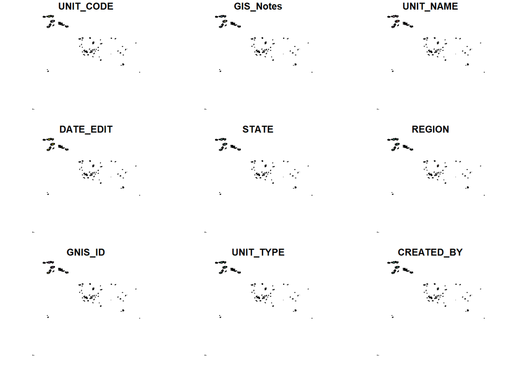

```r
ca_nat <- read_sf(dsn = ".", layer = "nps_boundary") %>% #read in data
  dplyr::filter(UNIT_TYPE == "National Park") #select only National Parks

st_crs(ca_nat) = 4326 #set coordinate reference system to 4326

plot(ca_nat)
```

Load Data: California Counties

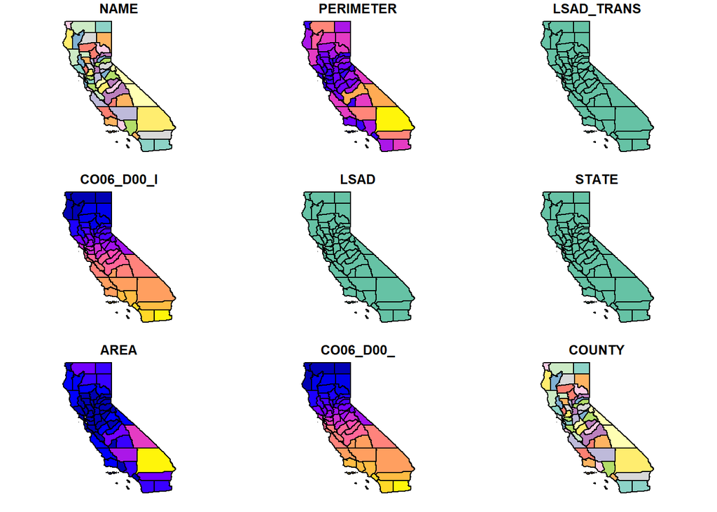

```r
ca_counties <- read_sf(dsn = ".", layer = "california_county_shape_file") #read in data

st_crs(ca_counties) = 4326 #set coordinate reference system to 4326

plot(ca_counties)
```

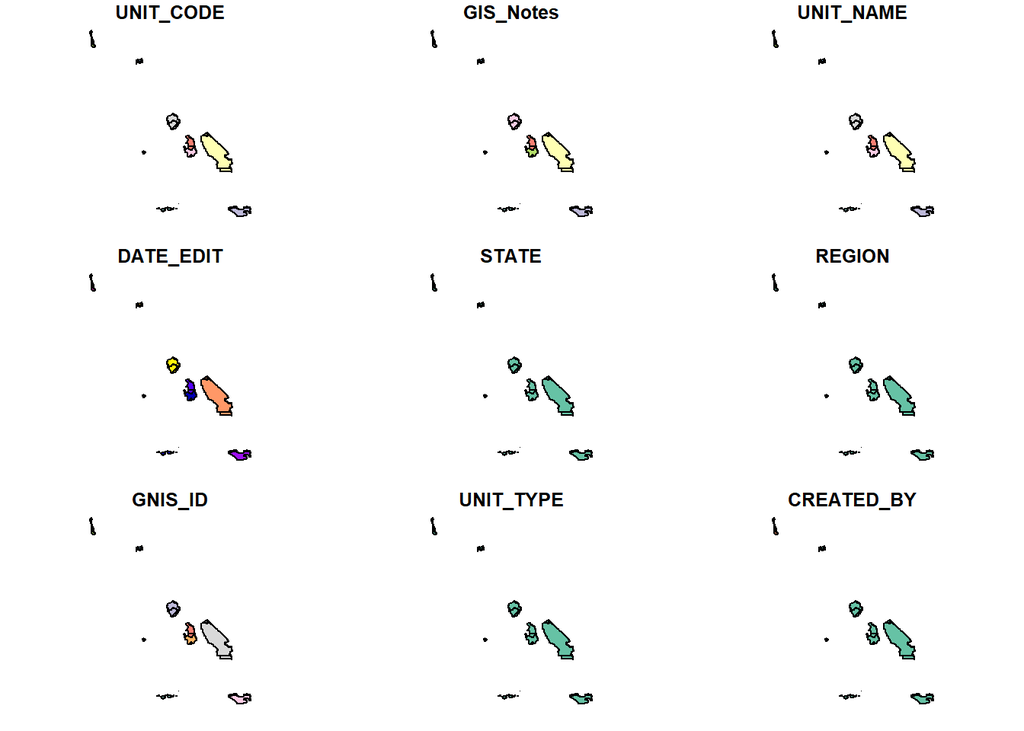

```r
nat_clip <- st_intersection(ca_nat, ca_counties) #crops to just CA
plot(nat_clip)
```

Select Unique Values in Park Names for Labels:

```r
parks <- st_centroid(nat_clip) #finds centroids of every Park
lab_coords <- st_coordinates(parks) #finds coords for labels
nat_labs <- cbind(parks, lab_coords)

lab_name <- nat_labs[-c(2, 4:9, 13, 16:21,24:26), ] #only selects unique park names. There are 9 different parks
lab_name$UNIT_NAME <- str_remove(lab_name$UNIT_NAME, "National Park")
```

Create a Map of National Parks:

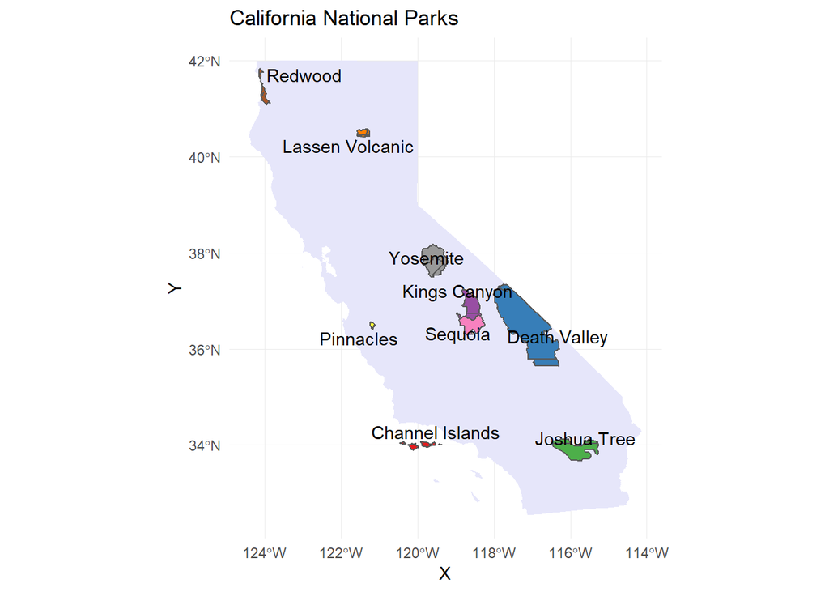

```r
ggplot()  +
  geom_sf(data = ca_counties,
          fill = "lavender",
          color = "NA") +
  geom_sf(data= nat_clip,
          aes(fill = UNIT_NAME),
          show.legend = FALSE) +
  scale_fill_brewer(palette = "Set1") +
  theme_minimal() +
  labs(title = "California National Parks") +
  geom_text_repel(data = lab_name,
                  aes(X, Y, label = UNIT_NAME))
```

## Part 4: Lizards in the Northern Chihuahuan Desert – Data Wrangling and Analysis

Read in Data:

```r
desert_lizard <- read_csv("lter_lizard_pitfall.csv") %>%
  filter(site == "CALI")
```

Data Wrangling: Do the weight of male and female lizards differ significantly?

```r
mf_liz <- desert_lizard %>%
  dplyr::select(sex,weight)

female <- mf_liz %>% #data frame for only female lizards
  filter(sex == "F")

f_liz <- female$weight #pull out all the female data in the weight column. only doing this bc t test fxn has to have values instead of data frame

#create a data set called male and a vector 'm' with weights only

male <- mf_liz %>%
  filter(sex == "M")

m_liz <- male$weight

f <- as.numeric(f_liz)
m <- as.numeric(m_liz)
```

Explore for normality:

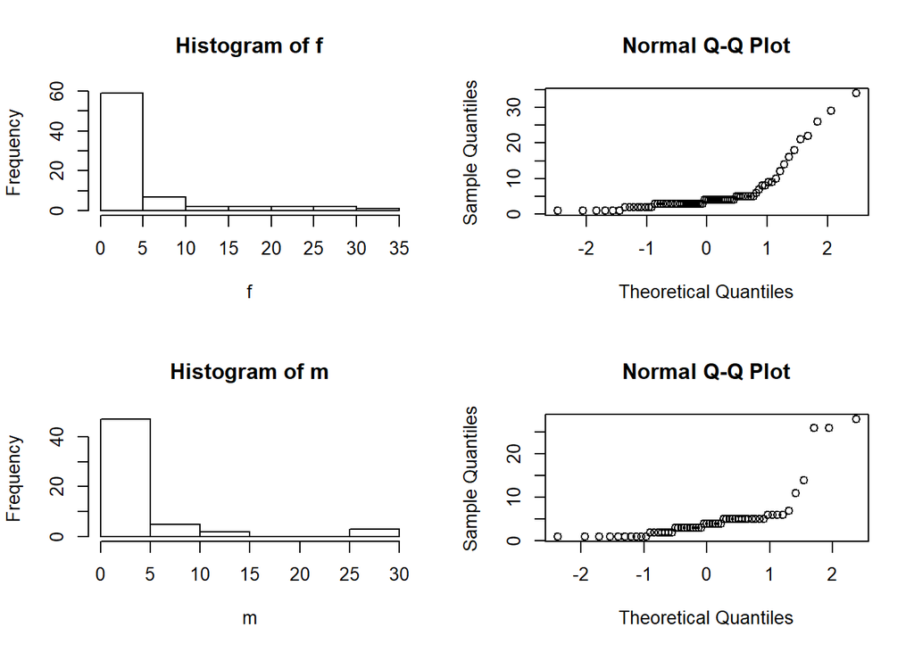

```r
#histogram and qqplot for f and m group
# have all 4 plots show up in one window

par(mfrow = c(2,2)) # number of rows, columns for the plots in one window
hist(f)
qqnorm(f)
hist(m)
qqnorm(m)
```

```r
#shapiro-wilk test for normality test the null hyp that data are normally distributed

shapiro.test(f)
```

```
##
##  Shapiro-Wilk normality test
##
## data:  f
## W = 0.61945, p-value = 1.211e-12
```

```r
shapiro.test(m)
```

```
##
##  Shapiro-Wilk normality test
##
## data:  m
## W = 0.57304, p-value = 1.282e-11
```

```r
#in this case reject null, so it's not normal dist
#in this case, still going to use a t test for this data bc of histograms, qqplots, and bc n >> 30 in both cases
```

F test for equal variances:

```r
# For F test:
#N0 = the ratio of sample variances equals 1 (variances are equal)
#H1: the ratio of sample variances is NOT 1 (variances not equal)

f_test <- var.test(f,m)
f_test
```

```
##
##  F test to compare two variances
##
## data:  f and m
## F = 1.3086, num df = 74, denom df = 56, p-value = 0.2938
## alternative hypothesis: true ratio of variances is not equal to 1
## 95 percent confidence interval:
##  0.7905084 2.1292094
## sample estimates:
## ratio of variances
##           1.308556
```

```r
#with p value of 0.2938, retain the null that our sample variances are equal
```

Two-sample t tests to compare means:

```r
t_test_diff <- t.test(f,m,var.equal = TRUE) # var.equal bc we est. eq var in f test
t_test_diff
```

```
##
##  Two Sample t-test
##
## data:  f and m
## t = 0.79647, df = 130, p-value = 0.4272
## alternative hypothesis: true difference in means is not equal to 0
## 95 percent confidence interval:
##  -1.278780  3.002289
## sample estimates:
## mean of x mean of y
##  5.826667  4.964912
```

If the mean weight of females and males is the same, the probablity that we could get means at least this different by random chance is 42.7%.

Is there a significant difference in the proportion of adult female and male lizards with broken tails?

```r
tail_cond <- desert_lizard %>%
  dplyr::select(sex, tail) %>%
  dplyr::filter(sex != "J", sex != ".", tail != ".")

male_broke <- tail_cond %>%
  dplyr::filter(sex == "M", tail == "B")
male_whole <- tail_cond %>%
  dplyr::filter(sex == "M", tail == "W")

female_broke <- tail_cond %>%
  dplyr::filter(sex == "F", tail == "B")
female_whole <- tail_cond %>%
  dplyr::filter(sex == "F", tail == "W")

MT <- c(46, 10)
FT <- c(59, 18)
tail_table <- rbind(MT, FT) #makes a table of the vectors
colnames(tail_table) <- c("Whole", "Broken")
rownames(tail_table) <- c("Male", "Female")

tail_table
```

```
##        Whole Broken
## Male      46     10
## Female    59     18
```

Table of Proportions:

```r
tail_prop <- prop.table(tail_table, margin = 1) #find the proportion of the data in each option by row
tail_prop
```

```
##            Whole    Broken
## Male   0.8214286 0.1785714
## Female 0.7662338 0.2337662
```

Hypothesis Testing:

H0: The proportiona of lizards with broken tails trapped in California is independent of sex. HA: The proportiona of lizards with broken tails trapped in California is dependent of sex.

```r
tail_chi <-chisq.test(tail_table)
tail_chi
```

```
##
##  Pearson's Chi-squared test with Yates' continuity correction
##
## data:  tail_table
## X-squared = 0.30857, df = 1, p-value = 0.5786
```

```r
#p value = 0.5786
```

There is no significant association between the proportion of lizards with broken tails trapped in California and sex ($\chi$<sup>2</sup>(1) = 0.309, $p$ = .5786, $\alpha$ = 0.05). Notably, fewer lizards are seen with broken tail than with whole tails for both sexes. Although it is not significant, more trapped females have been found with broken tails than trapped males.